# Project3: ML Exercise on Titanic Dataset

Group 2 崔芷瑄 韓曙憶 鄭富鴻

# 1 Executive Summary

Firstly we simply used an identity predictor showing whether the person was on life boat or not, and found out in all the three models the predictive results were same: people on life boat would survive and the rest would die.

Then we looked into the survival rate of different boats and classified them into a predictor showing the safe level of the boat.

For prediction, we chose 4 predictors: BSafe (the suvival rate of each boat), PclassSex, GroupSize and FarePP, and applied three models: RM, SVM & GBM.

In the training data, the results of SVM model and GBM model significantly have larger counts of false predictions.

In the testing data, SVM model model predicts all those getting on life boat survived and the rest died. The result of GBM model is basiclly the same except the only one passenger on boat A is predicted to be dead, while in RF model there are 8 person who didn’t get on life boat but survived (which are closer to the situation showed in the trainning dataset).

Therefore we choose to merge the results of RF & GBM model and use it as our final result.

# 2 Loading and Exploring Data

## 2.1 Loading libraries required and reading the data into R

Loading R packages used besides base R.

```r
library(Hmisc)
library(knitr)
library(ggplot2)
library(dplyr)
library(caret)
library(randomForest)
library(gridExtra)
library(ROCR)
library(corrplot)
library(gbm)
```

Reading the csv’s as dataframes into R.

```r
train <- read.csv("titanicTrain.csv", stringsAsFactors = F, na.strings = c("NA", ""))
test <- read.csv("titanicQuestion.csv", stringsAsFactors = F, na.strings = c("NA", ""))
train <- train[1:1000,]
```

## 2.2 Data size and structure

Showing summaries:

```r
str(train)
```

```
## 'data.frame':    1000 obs. of  14 variables:
##  $ pclass   : int  1 1 1 1 1 1 1 1 1 1 ...
##  $ survived : int  1 1 0 0 0 1 1 0 1 0 ...
##  $ name     : chr  "Allen, Miss. Elisabeth Walton" "Allison, Master. Hudson Trevor" "Allison, Miss. Helen Loraine" "Allison, Mr. Hudson Joshua Creighton" ...
##  $ sex      : chr  "female" "male" "female" "male" ...
##  $ age      : num  29 0.917 2 30 25 ...
##  $ sibsp    : int  0 1 1 1 1 0 1 0 2 0 ...
##  $ parch    : int  0 2 2 2 2 0 0 0 0 0 ...
##  $ ticket   : chr  "24160" "113781" "113781" "113781" ...
##  $ fare     : num  211 152 152 152 152 ...
##  $ cabin    : chr  "B5" "C22 C26" "C22 C26" "C22 C26" ...
##  $ embarked : chr  "S" "S" "S" "S" ...
##  $ boat     : chr  "2" "11" NA NA ...
##  $ body     : int  NA NA NA 135 NA NA NA NA NA 22 ...
##  $ home.dest: chr  "St Louis, MO" "Montreal, PQ / Chesterville, ON" "Montreal, PQ / Chesterville, ON" "Montreal, PQ / Chesterville, ON" ...
```

Merging test and train:

```r
all <- rbind(train, test)
```

## 2.3 Exploration and Feature Engineering

```r
all$sex <- as.factor(all$sex)
all$survived <- as.factor(all$survived)
all$pclass <- as.ordered(all$pclass)
```

### 2.3.1 The response variable; survived

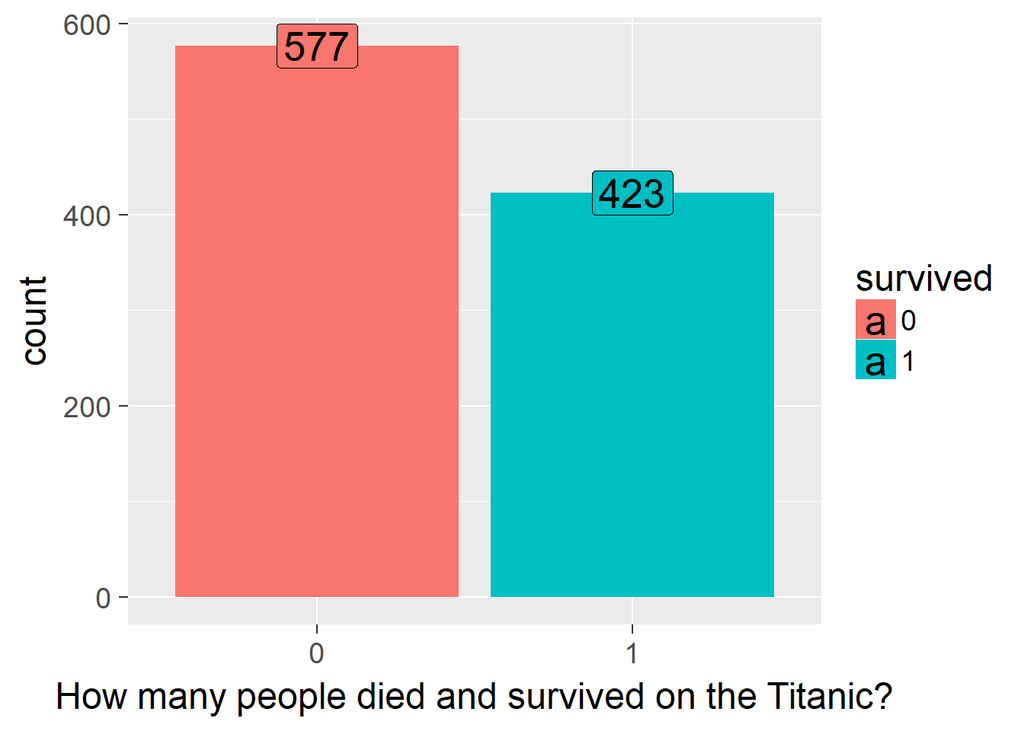

```r
ggplot(all[!is.na(all$survived),], aes(x = survived, fill = survived)) +
  geom_bar(stat='count') +
  labs(x = 'How many people died and survived on the Titanic?') +
        geom_label(stat='count',aes(label=..count..), size=7) +
        theme_grey(base_size = 18)
```

### 2.3.2 whether gets on life boat and the safe index of the boat

Firstly we simply used an identity predictor showing whether the person was on life boat or not, and found out in all the three models the predictive results were same: people on life boat would survive and the rest would die. Then we looked into the survival rate of diffrent boats and classified them into a predictor showing the safe level of the boat.

```r
all$onboat <- !is.na(all$boat)
all$boat[is.na(all$boat)]<-"0"
```

```r
all$boat<-as.factor(all$boat)
```

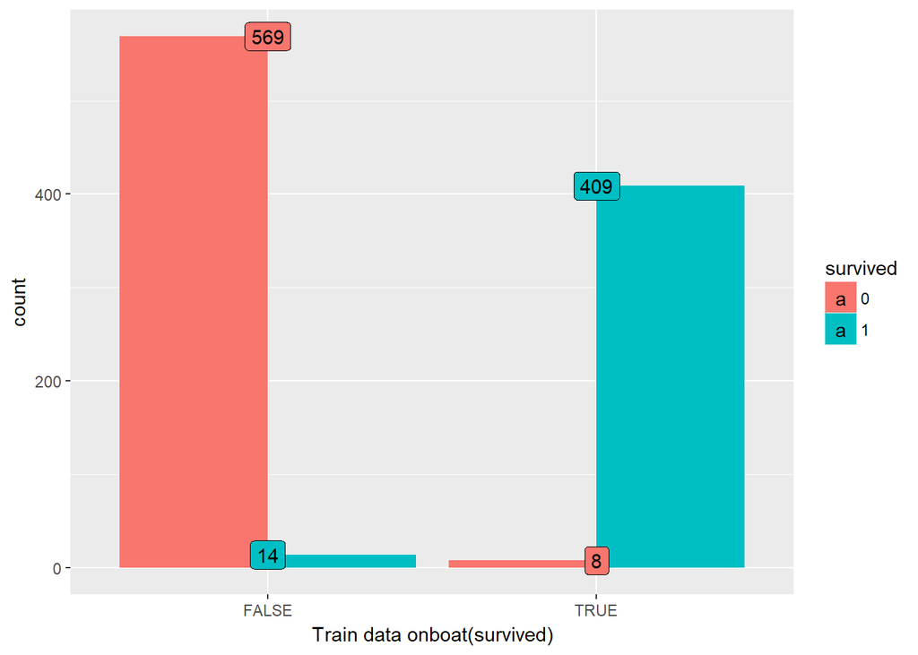

```r
# onboat(survived)
ggplot(all[!is.na(all$survived),], aes(x = onboat, fill = survived)) +
  geom_bar(stat='count', position='dodge') + theme_grey() +
  labs(x = 'Train data onboat(survived)') +
  geom_label(stat='count', aes(label=..count..))
```

Almost all people got on boat survived and the rest died.

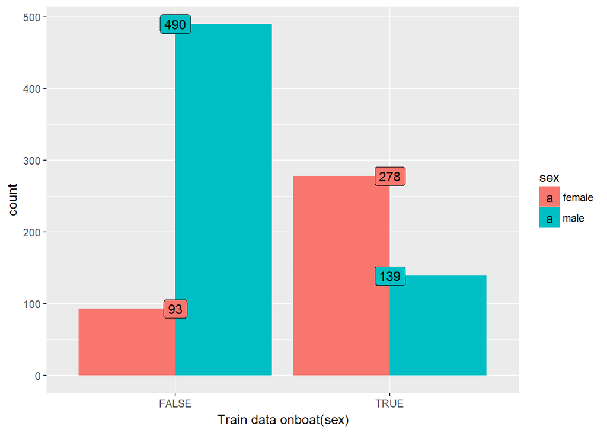

```r
# onboat(sex)
ggplot(all[!is.na(all$survived),], aes(x = onboat, fill = sex)) +
  geom_bar(stat='count', position='dodge') + theme_grey() +
  labs(x = 'Train data onboat(sex)') +
  geom_label(stat='count', aes(label=..count..))
```

Women has a higher rate of getting on life boat.

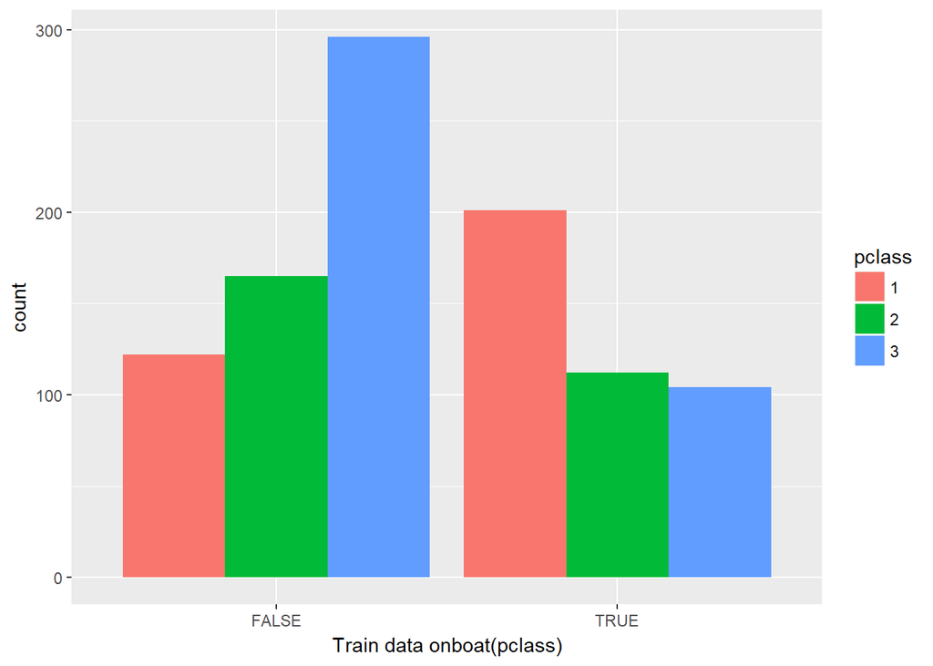

```r
# onboat(pclass)
ggplot(all[!is.na(all$survived),], aes(x = onboat, fill = pclass)) +
  geom_bar(stat='count', position='dodge') + theme_grey() +
  labs(x = 'Train data onboat(pclass)')
```

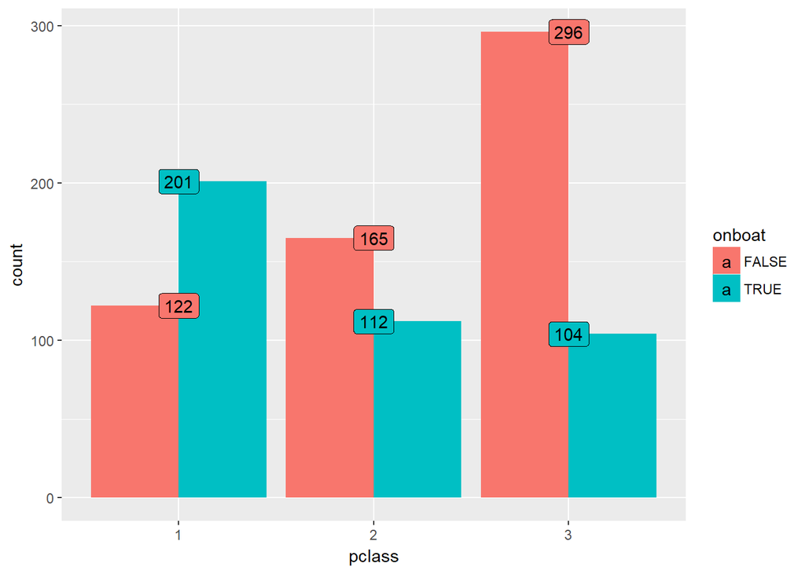

```r
ggplot(all[!is.na(all$survived),],aes(x=pclass,fill=onboat))+
  geom_bar(stat='count',position = position_dodge())+
  theme_grey()+
  geom_label(stat = 'count',aes(label=..count..))
```

Those people in higher passenger class have a higher odd to getting on life boat.

```r
all$onboat = all$onboat *1
```

Check the survival rate on different boats:

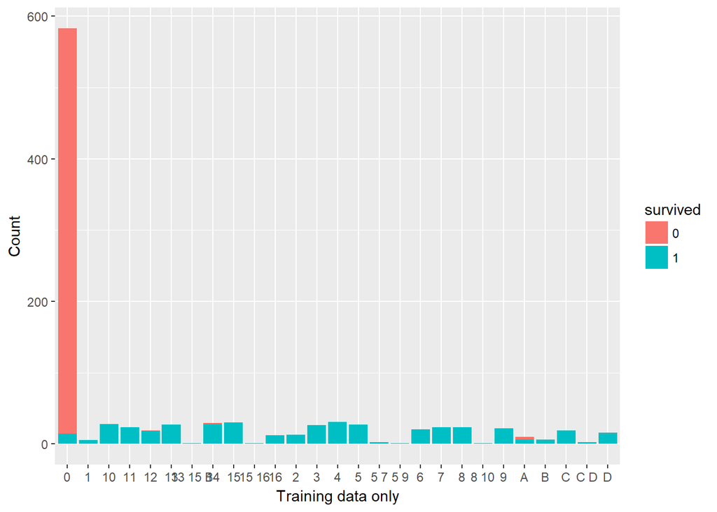

```r
ggplot(all[!is.na(all$survived),], aes(x = boat, fill = survived))+    geom_bar(stat='count', position='stack') +
   labs(x = 'Training data only', y= "Count") +
         theme(legend.position="none") +
     theme_grey()
```

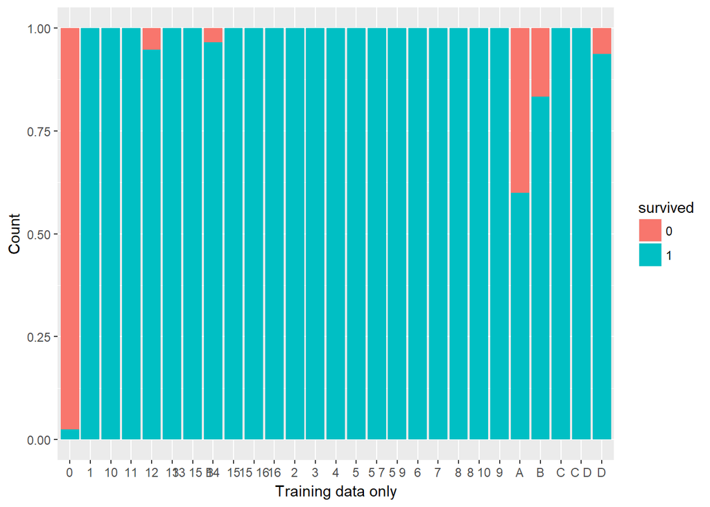

```r
ggplot(all[!is.na(all$survived),], aes(x = boat, fill = survived))+
   geom_bar(stat='count', position='fill') +
   labs(x = 'Training data only', y= "Count") +
        theme(legend.position="none") + theme_grey()
```

Calculate the survival rate of each boat(treat 0 as one boat too):

```r
boat_surv_rate<-all %>%
  filter(!is.na(all$survived)) %>%
  group_by(boat,survived) %>%
  summarise(Percentage=n()) %>%
  group_by(boat) %>%
  mutate(Percentage=Percentage/sum(Percentage)*100)
boat_surv_rate <- boat_surv_rate[boat_surv_rate$survived==1,]
boat_surv_rate[with(boat_surv_rate,order(Percentage)),]
```

```
## # A tibble: 27 x 3
## # Groups:   boat [27]
##    boat  survived Percentage
##    <fct> <fct>         <dbl>
##  1 0     1              2.40
##  2 A     1             60
##  3 B     1             83.3
##  4 D     1             93.8
##  5 12    1             94.7
##  6 14    1             96.6
##  7 1     1            100
##  8 10    1            100
##  9 11    1            100
## 10 13    1            100
## # ... with 17 more rows
```

Create a predictor showing safe index of each boat:

```r
all$BSafe <- 100
all$BSafe[all$boat=="0"] <-2.4
all$BSafe[all$boat=="A"] <-60.0
all$BSafe[all$boat=="B"] <-83.3
all$BSafe[all$boat=="D"] <-93.8
all$BSafe[all$boat=="12"] <-94.7
all$BSafe[all$boat=="14"] <-96.6
```

### 2.3.3 Sex/gender

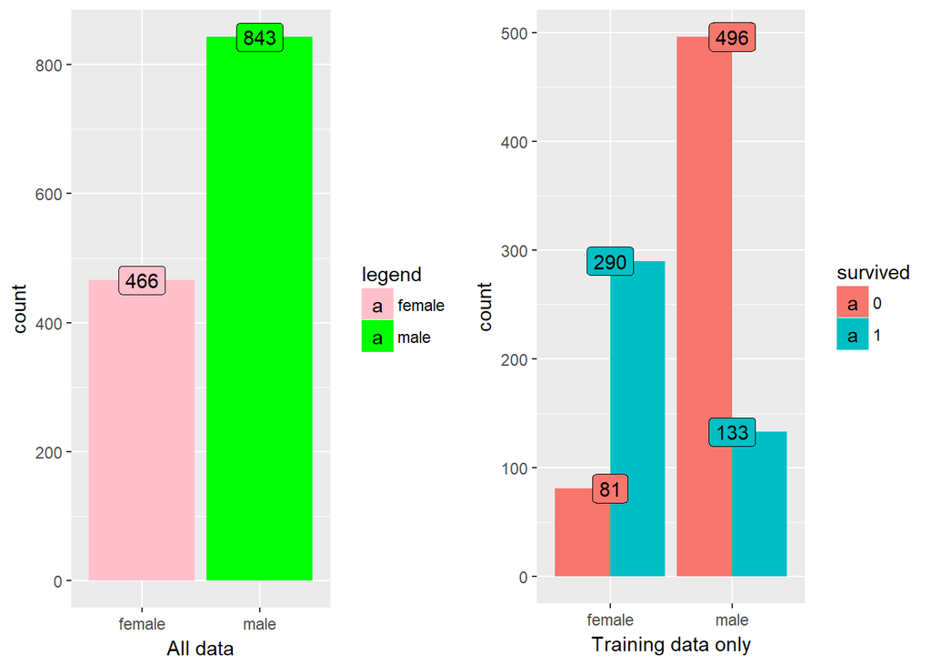

```r
p1 <- ggplot(all, aes(x = sex, fill = sex)) +
  geom_bar(stat='count', position='dodge') + theme_grey() +
  labs(x = 'All data') +
        geom_label(stat='count', aes(label=..count..)) +
        scale_fill_manual("legend", values = c("female" = "pink", "male" = "green"))
p2 <- ggplot(all[!is.na(all$survived),], aes(x = sex, fill = survived)) +
  geom_bar(stat='count', position='dodge') + theme_grey() +
  labs(x = 'Training data only') +
        geom_label(stat='count', aes(label=..count..))

grid.arrange(p1,p2, nrow=1)
```

### 2.3.4 Passenger Class

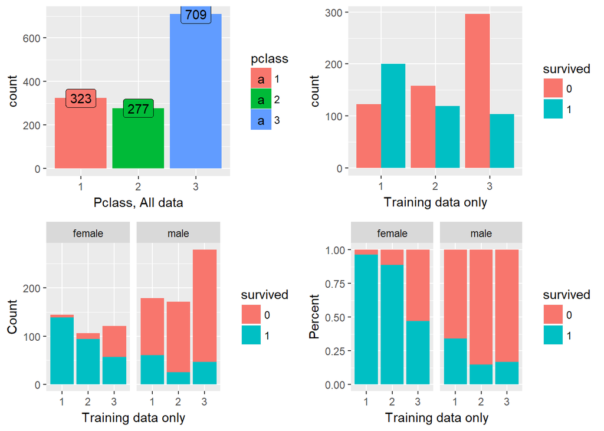

```r
p3 <- ggplot(all, aes(x = pclass, fill = pclass)) +
  geom_bar(stat='count', position='dodge') +
  labs(x = 'Pclass, All data') + geom_label(stat='count', aes(label=..count..)) +
   theme(legend.position="none") + theme_grey()
p4 <- ggplot(all[!is.na(all$survived),], aes(x = pclass, fill = survived)) +
  geom_bar(stat='count', position='dodge') + labs(x = 'Training data only') +
        theme(legend.position="none") + theme_grey()
p5 <- ggplot(all[!is.na(all$survived),], aes(x = pclass, fill = survived)) +
  geom_bar(stat='count', position='stack') +
  labs(x = 'Training data only', y= "Count") + facet_grid(.~sex) +
        theme(legend.position="none") + theme_grey()
p6 <- ggplot(all[!is.na(all$survived),], aes(x = pclass, fill = survived)) +
  geom_bar(stat='count', position='fill') +
  labs(x = 'Training data only', y= "Percent") + facet_grid(.~sex) +
        theme(legend.position="none") + theme_grey()

grid.arrange(p3, p4, p5, p6, ncol=2)
```

Combine Pclass and Sex as an predictor

```r
all$PclassSex[all$pclass=='1' & all$sex=='male'] <- 'P1Male'
all$PclassSex[all$pclass=='2' & all$sex=='male'] <- 'P2Male'
all$PclassSex[all$pclass=='3' & all$sex=='male'] <- 'P3Male'
all$PclassSex[all$pclass=='1' & all$sex=='female'] <- 'P1Female'
all$PclassSex[all$pclass=='2' & all$sex=='female'] <- 'P2Female'
all$PclassSex[all$pclass=='3' & all$sex=='female'] <- 'P3Female'
all$PclassSex <- as.factor(all$PclassSex)
```

### 2.3.5 the Title variable

Separate title and name

```r
#Extracting Title and Surname from Name
all$Surname <- sapply(all$name, function(x) {strsplit(x, split='[,.]')[[1]][1]})
 #correcting some surnames that also include a maiden name
all$Surname <- sapply(all$Surname, function(x) {strsplit(x, split='[-]')[[1]][1]})
all$Title <- sapply(all$name, function(x) {strsplit(x, split='[,.]')[[1]][2]})
all$Title <- sub(' ', '', all$Title) #removing spaces before title
kable(table(all$sex, all$Title))
```

|  | Capt | Col | Don | Dona | Dr | Jonkheer | Lady | Major | Master | Miss | Mlle | Mme | Mr | Mrs | Ms | Rev | Sir | the Countess |
| --- | --- | --- | --- | --- | --- | --- | --- | --- | --- | --- | --- | --- | --- | --- | --- | --- | --- | --- |
| female | 0 | 0 | 0 | 1 | 1 | 0 | 1 | 0 | 0 | 260 | 2 | 1 | 0 | 197 | 2 | 0 | 0 | 1 |
| male | 1 | 4 | 1 | 0 | 7 | 1 | 0 | 2 | 61 | 0 | 0 | 0 | 757 | 0 | 0 | 8 | 1 | 0 |

reducing the number of titles to create better and more substantial Titles that can be used for prediction.

```r
all$Title[all$Title %in% c("Mlle", "Ms")] <- "Miss"
all$Title[all$Title== "Mme"] <- "Mrs"
all$Title[!(all$Title %in% c('Master', 'Miss', 'Mr', 'Mrs'))] <- "Rare Title"
all$Title <- as.factor(all$Title)
kable(table(all$sex, all$Title))
```

|  | Master | Miss | Mr | Mrs | Rare Title |
| --- | --- | --- | --- | --- | --- |
| female | 0 | 264 | 0 | 198 | 4 |
| male | 61 | 0 | 757 | 0 | 25 |

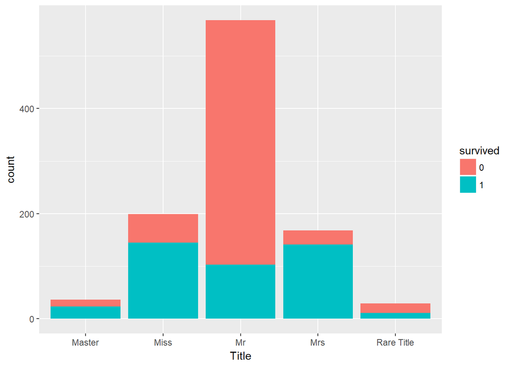

```r
ggplot(all[!is.na(all$survived),], aes(x = Title, fill = survived)) +
  geom_bar(stat='count', position='stack') +
  labs(x = 'Title') +theme_grey()
```

### 2.3.6 Group size (max of family size and ticket size)

family size

```r
#creating family size variable (Fsize)
all$Fsize <- all$sibsp+all$parch +1
```

Solo travelers had a much higher chance to die than to survive. In addition, people traveling in families of 2-4 people actually had a relatively high chance to survive. This chance is significantly lower among 5+ families.

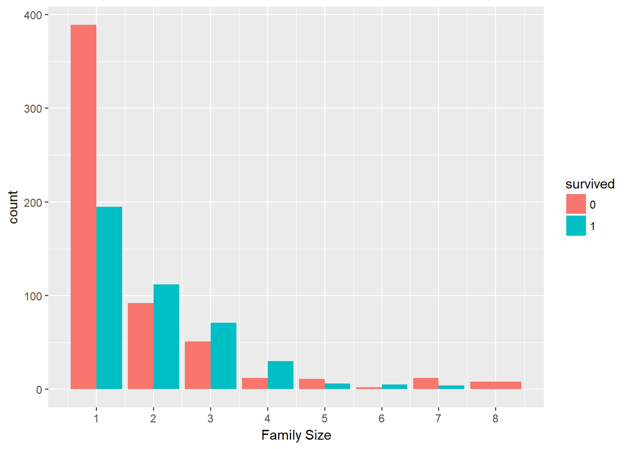

```r
ggplot(all[!is.na(all$survived),], aes(x = Fsize, fill = survived)) +
  geom_bar(stat='count', position='dodge') +
  scale_x_continuous(breaks=c(1:11)) +
  labs(x = 'Family Size') + theme_grey()
```

ticket size

adding the number of people on each ticket as variable.

```r
#composing data frame with group size for each Ticket
TicketGroup <- all %>%
        select(ticket) %>%
        group_by(ticket) %>%
        summarise(Tsize=n())
all <- left_join(all, TicketGroup, by = "ticket")
```

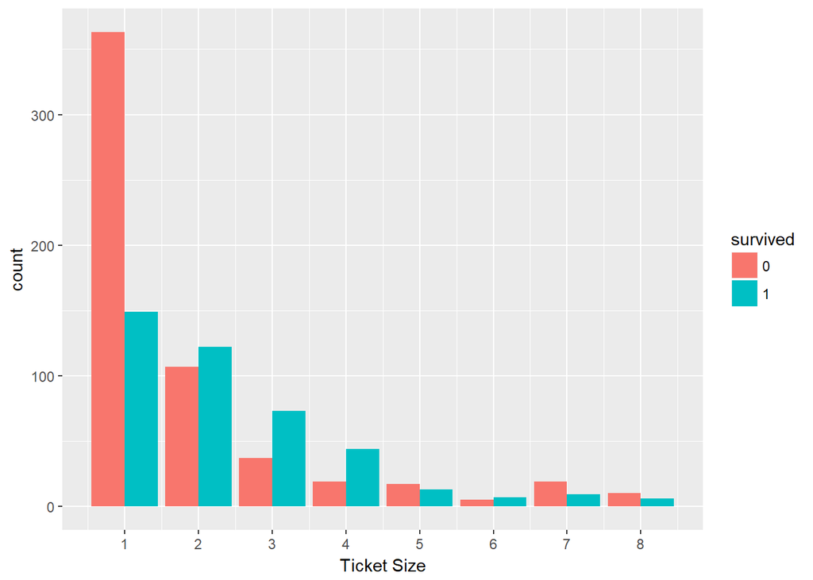

```r
ggplot(all[!is.na(all$survived),], aes(x = Tsize, fill = survived)) +
  geom_bar(stat='count', position='dodge') +
  scale_x_continuous(breaks=c(1:11)) +
  labs(x = 'Ticket Size') + theme_grey()
```

created factorized variable for the group sizes.

```r
#taking the max of family and ticket size as the group size
all$Group <- all$Fsize
for (i in 1:nrow(all)){
           all$Group[i] <- max(all$Group[i], all$Tsize[i])
}

#Creating final group categories
all$GroupSize[all$Group==1] <- 'solo'
all$GroupSize[all$Group==2] <- 'duo'
all$GroupSize[all$Group>=3 & all$Group<=4] <- 'group'
all$GroupSize[all$Group>=5] <- 'large group'
all$GroupSize <- as.factor(all$GroupSize)
```

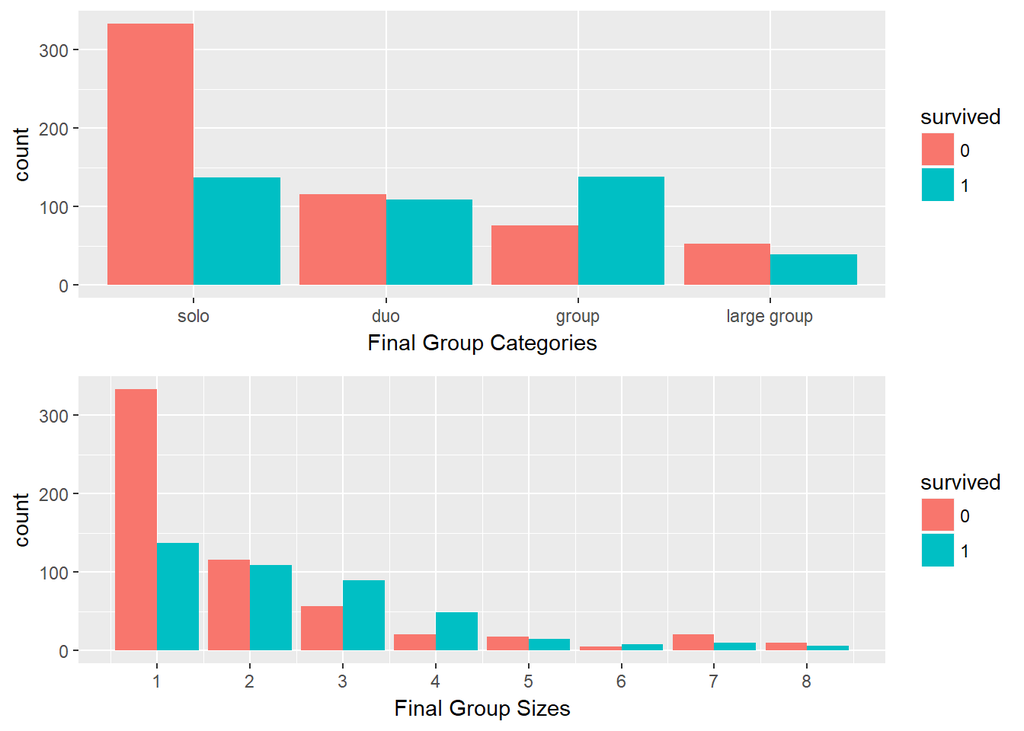

```r
g1 <- ggplot(all[!is.na(all$survived),], aes(x = Group, fill = survived)) +
  geom_bar(stat='count', position='dodge') +
  scale_x_continuous(breaks=c(1:11)) +
  labs(x = 'Final Group Sizes') + theme_grey()

g2 <- ggplot(all[!is.na(all$survived),], aes(x = GroupSize, fill = survived)) +
  geom_bar(stat='count', position='dodge') +
  labs(x = 'Final Group Categories') + theme_grey() +
        scale_x_discrete (limits = c('solo', 'duo', 'group', 'large group'))
grid.arrange(g2, g1)
```

### 2.3.7 the FarePP variable

deal with the missing values

```r
#display passengers with missing Embarked
kable(all[which(is.na(all$embarked)),c('Surname', 'Title', 'survived', 'pclass', 'age', 'sibsp', 'parch', 'ticket', 'fare', 'cabin', 'embarked', 'Group') ])
```

|  | Surname | Title | survived | pclass | age | sibsp | parch | ticket | fare | cabin | embarked | Group |
| --- | --- | --- | --- | --- | --- | --- | --- | --- | --- | --- | --- | --- |
| 169 | Icard | Miss | 1 | 1 | 38 | 0 | 0 | 113572 | 80 | B28 | NA | 2 |
| 285 | Stone | Mrs | 1 | 1 | 62 | 0 | 0 | 113572 | 80 | B28 | NA | 2 |

impute the missing embarkement city with the median Fare Per Person for each Embarkement city, and per Pclass.

```r
all$FarePP <- all$fare/all$Tsize #creating the Fare Per Person variable

tab2 <- all[(!is.na(all$embarked) & !is.na(all$fare)),] %>%
        group_by(embarked, pclass) %>%
        summarise(FarePP=median(FarePP))
kable(tab2)
```

| embarked | pclass | FarePP |
| --- | --- | --- |
| C | 1 | 34.6500 |
| C | 2 | 13.8583 |
| C | 3 | 7.2271 |
| Q | 1 | 30.0000 |
| Q | 2 | 12.3500 |
| Q | 3 | 7.7500 |
| S | 1 | 26.5500 |
| S | 2 | 11.5000 |
| S | 3 | 7.7958 |

As the FarePP of those two women is 40, they most likely embarked at Cherbourgh.

```r
#imputing missing Embarked values
all$embarked[all$ticket=='113572'] <- 'C'
#converting Embarked into a factor
all$embarked <- as.factor(all$embarked)
```

I can actually use the same table to find a sensible fare for Mr Story. As you can see below, he traveled 3rd class and embarked at Southampton.

```r
#display passengers with missing Fare
kable(all[which(is.na(all$fare)), c('Surname', 'Title', 'survived', 'pclass', 'age', 'sibsp', 'parch', 'ticket', 'fare', 'cabin', 'embarked', 'Group','FarePP')])
```

|  | Surname | Title | survived | pclass | age | sibsp | parch | ticket | fare | cabin | embarked | Group | FarePP |
| --- | --- | --- | --- | --- | --- | --- | --- | --- | --- | --- | --- | --- | --- |
| 1226 | Storey | Mr | NA | 3 | 60.5 | 0 | 0 | 3701 | NA | NA | S | 1 | NA |

```r
#imputing FarePP (as the Fare will be dropped later on anyway)
all$FarePP[1226] <- 7.8
```

The Fare Per Person Variable

adjust zero fare value: replacing these values by the median FarePP’s for each Pclass.

```r
tab3 <- all[(!is.na(all$FarePP)),] %>%
        group_by(pclass) %>%
        summarise(MedianFarePP=median(FarePP))
all <- left_join(all, tab3, by = "pclass")
all$FarePP[which(all$FarePP==0)] <- all$MedianFarePP[which(all$FarePP==0)]
```

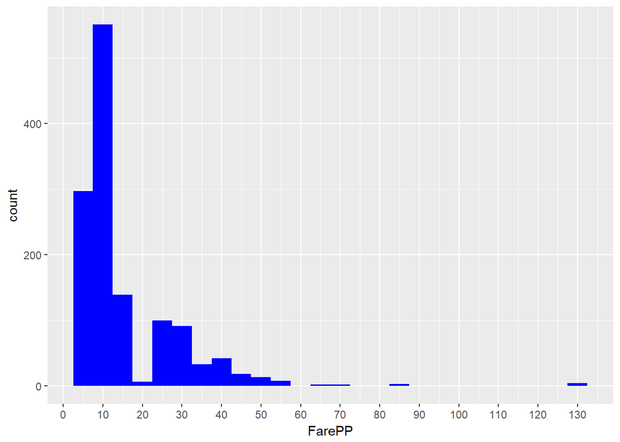

```r
ggplot(all, aes(x=FarePP)) +
        geom_histogram(binwidth = 5, fill='blue') + theme_grey() +
        scale_x_continuous(breaks= seq(0, 150, by=10))
```

# 3 Predictions

```r
#splitting data into train and test set again
trainClean <- all[1:1000,]
testClean <- all[1001:1309,]
```

## 3.1 Random Forest model

```r
set.seed(2017)
caret_matrix <- train(x=trainClean[,c('BSafe','PclassSex', 'GroupSize', 'FarePP')], y=trainClean$survived, data=trainClean, method='rf', trControl=trainControl(method="cv", number=5))
caret_matrix
```

```
## Random Forest
##
## 1000 samples
##    4 predictor
##    2 classes: '0', '1'
##
## No pre-processing
## Resampling: Cross-Validated (5 fold)
## Summary of sample sizes: 801, 799, 800, 800, 800
## Resampling results across tuning parameters:
##
##   mtry  Accuracy   Kappa
##   2     0.9769948  0.9527941
##   3     0.9769948  0.9528134
##   4     0.9789949  0.9569117
##
## Accuracy was used to select the optimal model using the largest value.
## The final value used for the model was mtry = 4.
```

```r
caret_matrix$results
```

```
##   mtry  Accuracy     Kappa  AccuracySD    KappaSD
## 1    2 0.9769948 0.9527941 0.009091295 0.01855809
## 2    3 0.9769948 0.9528134 0.009091295 0.01857960
## 3    4 0.9789949 0.9569117 0.011939410 0.02441263
```

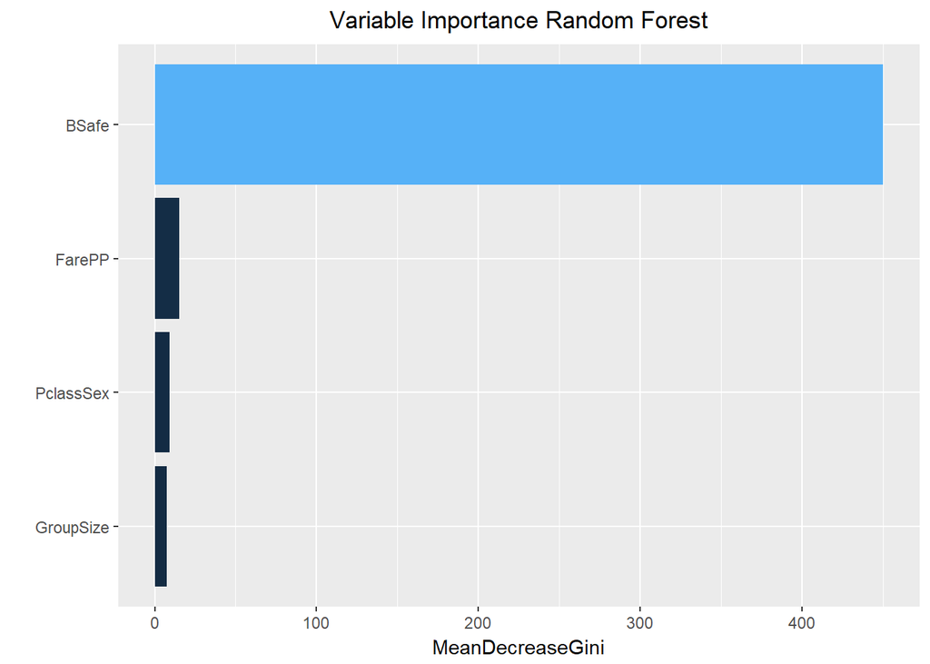

```r
#extracting variable importance and make graph with ggplot (looks nicer that the standard varImpPlot)
rf_imp <- varImp(caret_matrix, scale = FALSE)
rf_imp <- rf_imp$importance
rf_gini <- data.frame(Variables = row.names(rf_imp), MeanDecreaseGini = rf_imp$Overall)

ggplot(rf_gini, aes(x=reorder(Variables, MeanDecreaseGini), y=MeanDecreaseGini, fill=MeanDecreaseGini)) +
        geom_bar(stat='identity') + coord_flip() + theme(legend.position="none") + labs(x="") +
        ggtitle('Variable Importance Random Forest') + theme(plot.title = element_text(hjust = 0.5))
```

```r
#using the model to make Survival predictions on the test set
solution_rf <- predict(caret_matrix, testClean)
```

## 3.2 Support Vector Machine (SVM) model

```r
set.seed(2017)
caret_svm <- train(survived~ BSafe+PclassSex + GroupSize+ FarePP, data=trainClean, method='svmRadial', preProcess= c('center', 'scale'), trControl=trainControl(method="cv", number=3))
caret_svm
```

```
## Support Vector Machines with Radial Basis Function Kernel
##
## 1000 samples
##    4 predictor
##    2 classes: '0', '1'
##
## Pre-processing: centered (10), scaled (10)
## Resampling: Cross-Validated (3 fold)
## Summary of sample sizes: 666, 667, 667
## Resampling results across tuning parameters:
##
##   C     Accuracy   Kappa
##   0.25  0.9770129  0.9528212
##   0.50  0.9780139  0.9548385
##   1.00  0.9770129  0.9527981
##
## Tuning parameter 'sigma' was held constant at a value of 0.1003025
## Accuracy was used to select the optimal model using the largest value.
## The final values used for the model were sigma = 0.1003025 and C = 0.5.
```

```r
caret_svm$results
```

```
##       sigma    C  Accuracy     Kappa AccuracySD    KappaSD
## 1 0.1003025 0.25 0.9770129 0.9528212 0.01130744 0.02335869
## 2 0.1003025 0.50 0.9780139 0.9548385 0.01207420 0.02490889
## 3 0.1003025 1.00 0.9770129 0.9527981 0.01130744 0.02334335
```

```r
#using the model to make Survival predictions on the test set
solution_svm <- predict(caret_svm, testClean)
```

## 3.3 Gradient Boosting Machine (GBM) model

```r
set.seed(2017)
caret_boost <- train(survived~ BSafe + PclassSex + GroupSize + FarePP , data=trainClean, method='gbm', preProcess= c('center', 'scale'), trControl=trainControl(method="cv", number=7), verbose=FALSE)
print(caret_boost)
```

```
## Stochastic Gradient Boosting
##
## 1000 samples
##    4 predictor
##    2 classes: '0', '1'
##
## Pre-processing: centered (10), scaled (10)
## Resampling: Cross-Validated (7 fold)
## Summary of sample sizes: 857, 857, 857, 856, 858, 858, ...
## Resampling results across tuning parameters:
##
##   interaction.depth  n.trees  Accuracy   Kappa
##   1                   50      0.9769945  0.9527030
##   1                  100      0.9750035  0.9486886
##   1                  150      0.9759954  0.9507812
##   2                   50      0.9759955  0.9506030
##   2                  100      0.9770015  0.9526983
##   2                  150      0.9740045  0.9466257
##   3                   50      0.9760025  0.9506979
##   3                  100      0.9739974  0.9465778
##   3                  150      0.9729984  0.9445872
##
## Tuning parameter 'shrinkage' was held constant at a value of 0.1
##
## Tuning parameter 'n.minobsinnode' was held constant at a value of 10
## Accuracy was used to select the optimal model using the largest value.
## The final values used for the model were n.trees = 100,
##  interaction.depth = 2, shrinkage = 0.1 and n.minobsinnode = 10.
```

```r
#using the model to make Survival predictions on the test set
solution_boost <- predict(caret_boost, testClean)
```

## 3.4 Correlations of the results from the three models:

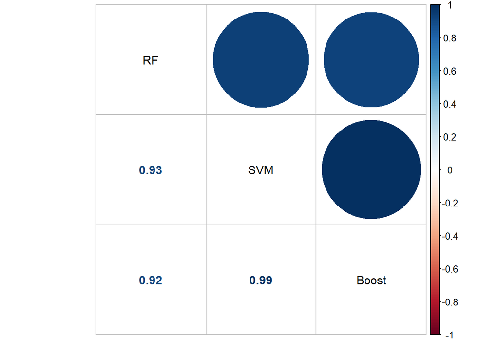

```r
#adding model predictions to test dataframe
testClean$RF <- as.numeric(solution_rf)-1
testClean$SVM <- as.numeric(solution_svm)-1
testClean$Boost <- as.numeric(solution_boost)-1

#compose correlations plot
corrplot.mixed(cor(testClean[, c('RF', 'SVM', 'Boost')]), order="hclust", tl.col="black")
```

## 3.5 Show the performance of these three model:

Blue:false positives (predicted to survive, but died). Red: False Negatives (predicted to die, but survived)

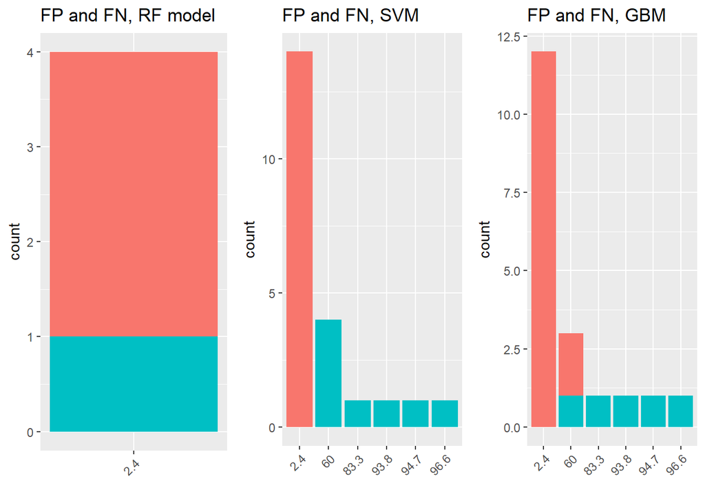

```r
#predictions of the models on the training set
trainClean$RF <- predict(caret_matrix, trainClean)
trainClean$SVM <- predict(caret_svm, trainClean)
trainClean$Boost <- predict(caret_boost, trainClean)


#plot differences between actual survived and predictions
f1 <- ggplot(trainClean[trainClean$survived != trainClean$RF,], aes(x=as.factor(BSafe), fill=RF)) +
        geom_bar(stat='count') + labs(title="FP and FN, RF model") + theme_grey() +
        theme(axis.text.x = element_text(angle = 45, hjust = 1)) +
        theme(legend.position="none") + xlab("")

f2 <- ggplot(trainClean[trainClean$survived != trainClean$SVM,], aes(x=as.factor(BSafe), fill=SVM)) +
        geom_bar(stat='count')+ labs(title="FP and FN, SVM") + theme_grey() +
        theme(axis.text.x = element_text(angle = 45, hjust = 1)) +
        theme(legend.position="none") + xlab("")

f3 <- ggplot(trainClean[trainClean$survived != trainClean$Boost,], aes(x=as.factor(BSafe), fill=Boost)) +
        geom_bar(stat='count')+ labs(title="FP and FN, GBM") + theme_grey() +
        theme(axis.text.x = element_text(angle = 45, hjust = 1)) +
        theme(legend.position="none") + xlab("")

grid.arrange(f1, f2, f3, nrow = 1)
```

# 4 Analysis and choose the final model

## 4.1 analysis:

On training data, the result of SVM model and GBM model are significantly have larger count of false predictions.

On the test data, SVM model model predict all those getting on life boat are survived and the rest died. The result of GBM model is basiclly the same except the only one passenger on boat A is predicted to be dead, while in RF model there are 8 person who didn’t get on life boat but survived (which are closer to the situation showed in the trainning dataset).

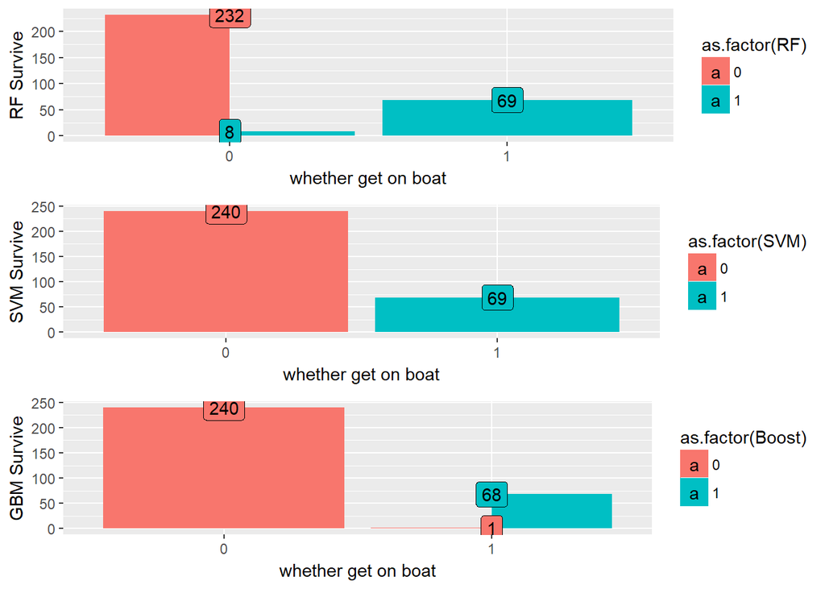

```r
pp1 = ggplot(testClean, aes(x = as.factor(onboat), fill = as.factor(RF))) +
  geom_bar(stat='count', position='dodge') + theme_grey() +
  labs(x = 'whether get on boat',y='RF Survive') +
  geom_label(stat='count', aes(label=..count..))

pp2 = ggplot(testClean, aes(x = as.factor(onboat), fill = as.factor(SVM))) +
  geom_bar(stat='count', position='dodge') + theme_grey() +
  labs(x = 'whether get on boat',y='SVM Survive') +
  geom_label(stat='count', aes(label=..count..))

pp3 = ggplot(testClean, aes(x = as.factor(onboat), fill = as.factor(Boost))) +
  geom_bar(stat='count', position='dodge') + theme_grey() +
  labs(x = 'whether get on boat',y='GBM Survive') +
  geom_label(stat='count', aes(label=..count..))

grid.arrange(pp1, pp2, pp3,ncol=1)
```

```r
#in RF model there are 8 person who didn't get on life boat but survived
testClean[testClean$onboat==FALSE &testClean$RF==1,]
```

```
##      pclass survived                                                 name
## 1008      3     <NA>                          McGowan, Miss. Anna "Annie"
## 1014      3     <NA>                       Meanwell, Miss. (Marion Ogden)
## 1015      3     <NA>              Meek, Mrs. Thomas (Annie Louise Rowley)
## 1059      3     <NA>                       Nieminen, Miss. Manta Josefina
## 1125      3     <NA>                                  Peters, Miss. Katie
## 1137      3     <NA>              Rasmussen, Mrs. (Lena Jacobsen Solvang)
## 1266      3     <NA>                            Van Impe, Miss. Catharina
## 1268      3     <NA> Van Impe, Mrs. Jean Baptiste (Rosalie Paula Govaert)
##         sex age sibsp parch            ticket    fare cabin embarked boat
## 1008 female  15     0     0            330923  8.0292  <NA>        Q    0
## 1014 female  NA     0     0 SOTON/O.Q. 392087  8.0500  <NA>        S    0
## 1015 female  NA     0     0            343095  8.0500  <NA>        S    0
## 1059 female  29     0     0           3101297  7.9250  <NA>        S    0
## 1125 female  NA     0     0            330935  8.1375  <NA>        Q    0
```

[output cut: 21 more lines]

```r
#in GBM model the only one passenger on boat A is predicted to be dead
testClean[testClean$onboat==TRUE &testClean$Boost==0,]
```

```
##      pclass survived                      name  sex age sibsp parch ticket
## 1089      3     <NA> Olsson, Mr. Oscar Wilhelm male  32     0     0 347079
##       fare cabin embarked boat body home.dest onboat BSafe PclassSex
## 1089 7.775  <NA>        S    A   NA      <NA>      1    60    P3Male
##      Surname Title Fsize Tsize Group GroupSize FarePP MedianFarePP RF SVM
## 1089  Olsson    Mr     1     1     1      solo  7.775         7.75  1   1
##      Boost
## 1089     0
```

Therefore we choose to merge the results of RF & GBM model and use it as our final result.

## 4.2 output result:

```r
test_result <- read.csv("titanicQuestion.csv", stringsAsFactors = F, na.strings = c("NA", ""))
testClean$result <-testClean$RF
testClean$result[testClean$onboat==TRUE &testClean$Boost==0] <-0
test_result$survived <- testClean$result
write.csv(test_result, file = "test_result.csv")
```